## Course: VISUAL ANALYTICS FOR POLICY AND MANAGEMENT

### Prof. José Manuel Magallanes, PhD

- Visiting Professor of Computational Policy at Evans School of Public Policy and Governance, and eScience Institute Senior Data Science Fellow, University of Washington.
- Professor of Government and Political Methodology, Pontificia Universidad Católica del Perú.

# Session 5: Tabular data: Bivariate Cat-Cat

We analyze two variables to find out if there might be some kind of association between them. Even though that may be difficult to clearly identify, bivariate analysis still helps reveal *signs* of association that may serve at least to raise concern.

As before, the nature of the data allows for some particular analytical techniques, while also providing some limitations to our inferences. Let’s see what we can visualize with the different combinations of data.

This time, I will use the [data about crime](https://data.seattle.gov/Public-Safety/Crime-Data/4fs7-3vj5) from the Seattle Open Data portal:

```r
# collecting the data
link="https://github.com/EvansDataScience/data/raw/master/crime.RData"
load(file = url(link))
```

The data available are:

```r
# seeing the variable names
names(crime)
```

```
##  [1] "Report.Number"               "Occurred.Date"
##  [3] "year"                        "month"
##  [5] "weekday"                     "Occurred.Time"
##  [7] "Occurred.DayTime"            "Reported.Date"
##  [9] "Reported.Time"               "DaysToReport"
## [11] "crimecat"                    "Crime.Subcategory"
## [13] "Primary.Offense.Description" "Precinct"
## [15] "Sector"                      "Beat"
## [17] "Neighborhood"
```

A quick look will give us:

```r
# checking first rows
head(crime)
```

```
##    Report.Number Occurred.Date year month weekday Occurred.Time
## 1 20130000244104    2013-07-09 2013     7 Tuesday          1930
## 2 20130000242916    2013-07-09 2013     7 Tuesday          1917
## 3 20130000904541    2013-07-09 2013     7 Tuesday          1900
## 4 20130000243875    2013-07-09 2013     7 Tuesday          1900
## 5 20130000242883    2013-07-09 2013     7 Tuesday          1846
## 6 20130000242880    2013-07-09 2013     7 Tuesday          1844
##   Occurred.DayTime Reported.Date Reported.Time DaysToReport
## 1          evening    2013-07-10          1722            1
## 2          evening    2013-07-09          2052            0
## 3          evening    2013-07-10            35            1
## 4          evening    2013-07-10          1258            1
## 5          evening    2013-07-09          1846            0
## 6          evening    2013-07-09          1849            0
##                    crimecat         Crime.Subcategory
## 1                  NARCOTIC                  NARCOTIC
## 2                  BURGLARY      BURGLARY-RESIDENTIAL
## 3                 CAR PROWL                 CAR PROWL
## 4                     THEFT       MOTOR VEHICLE THEFT
## 5 FAMILY OFFENSE-NONVIOLENT FAMILY OFFENSE-NONVIOLENT
## 6                  BURGLARY      BURGLARY-RESIDENTIAL
##   Primary.Offense.Description Precinct Sector Beat      Neighborhood
## 1     NARC-FRAUD-PRESCRIPTION    NORTH      U   U3         SANDPOINT
## 2        BURGLARY-NOFORCE-RES    NORTH      L   L3          LAKECITY
## 3              THEFT-CARPROWL    SOUTH      R   R2       MOUNT BAKER
## 4              VEH-THEFT-AUTO    NORTH      U   U3 ROOSEVELT/RAVENNA
## 5                 CHILD-OTHER     WEST      Q   Q2        QUEEN ANNE
## 6          BURGLARY-FORCE-RES     WEST      Q   Q2        QUEEN ANNE
```

Let’s see what kind of data we have:

```r
# checking data types
str(crime)#,width = 70,strict.width='cut')
```

```
## 'data.frame':    499698 obs. of  17 variables:
##  $ Report.Number              : chr  "20130000244104" "20130000242916" "20130000904541" "20130000243875" ...
##  $ Occurred.Date              : Date, format: "2013-07-09" "2013-07-09" ...
##  $ year                       : num  2013 2013 2013 2013 2013 ...
##  $ month                      : num  7 7 7 7 7 7 7 7 7 7 ...
##  $ weekday                    : Ord.factor w/ 7 levels "Monday"<"Tuesday"<..: 2 2 2 2 2 2 2 2 2 2 ...
##  $ Occurred.Time              : num  1930 1917 1900 1900 1846 ...
##  $ Occurred.DayTime           : Ord.factor w/ 4 levels "day"<"afternoon"<..: 3 3 3 3 3 3 3 3 3 3 ...
##  $ Reported.Date              : Date, format: "2013-07-10" "2013-07-09" ...
##  $ Reported.Time              : num  1722 2052 35 1258 1846 ...
##  $ DaysToReport               : num  1 0 1 1 0 0 0 0 1 0 ...
##  $ crimecat                   : Factor w/ 20 levels "AGGRAVATED ASSAULT",..: 12 3 4 18 7 3 18 18 4 18 ...
##  $ Crime.Subcategory          : Factor w/ 30 levels "AGGRAVATED ASSAULT",..: 17 6 8 16 11 6 28 28 8 28 ...
##  $ Primary.Offense.Description: Factor w/ 144 levels "ADULT-VULNERABLE-FINANCIAL",..: 53 21 124 133 30 19 131 131 124 131 ...
##  $ Precinct                   : Factor w/ 5 levels "EAST","NORTH",..: 2 2 3 2 5 5 5 4 5 2 ...
##  $ Sector                     : Factor w/ 23 levels "6804","9512",..: 21 12 17 21 16 16 13 7 11 12 ...
##  $ Beat                       : Factor w/ 64 levels "B1","B2","B3",..: 58 33 49 58 46 46 37 16 28 31 ...
##  $ Neighborhood               : Factor w/ 58 levels "ALASKA JUNCTION",..: 51 28 37 49 46 46 15 24 15 28 ...
```

We can also take a quick statistical look:

```r
# checking statistics
summary(crime)
```

```
##  Report.Number      Occurred.Date             year          month
##  Length:499698      Min.   :1908-12-13   Min.   :1908   Min.   : 1.000
##  Class :character   1st Qu.:2010-10-26   1st Qu.:2010   1st Qu.: 4.000
##  Mode  :character   Median :2013-10-16   Median :2013   Median : 7.000
##                     Mean   :2013-08-08   Mean   :2013   Mean   : 6.501
##                     3rd Qu.:2016-05-11   3rd Qu.:2016   3rd Qu.: 9.000
##                     Max.   :2018-11-06   Max.   :2018   Max.   :12.000
##                     NA's   :2            NA's   :2      NA's   :2
##       weekday       Occurred.Time   Occurred.DayTime  Reported.Date
##  Friday   : 77662   Min.   :   0   day      :108648   Min.   :1975-12-16
##  Saturday : 73340   1st Qu.: 900   afternoon:155725   1st Qu.:2010-11-02
##  Thursday : 71441   Median :1500   evening  :119061   Median :2013-10-21
##  Wednesday: 70898   Mean   :1360   night    :116262   Mean   :2013-08-16
##  Tuesday  : 70593   3rd Qu.:1922   NA's     :     2   3rd Qu.:2016-05-17
##  (Other)  :135762   Max.   :2359                      Max.   :2018-11-06
##  NA's     :     2   NA's   :2
##  Reported.Time   DaysToReport                    crimecat
##  Min.   :   0   Min.   :    0.00   THEFT             :170946
##  1st Qu.: 950   1st Qu.:    0.00   CAR PROWL         :142447
##  Median :1407   Median :    0.00   BURGLARY          : 76630
##  Mean   :1354   Mean   :    7.65   AGGRAVATED ASSAULT: 21315
##  3rd Qu.:1818   3rd Qu.:    1.00   NARCOTIC          : 16864
##  Max.   :2359   Max.   :36525.00   (Other)           : 71234
##  NA's   :2      NA's   :2          NA's              :   262
##             Crime.Subcategory      Primary.Offense.Description
##  CAR PROWL           :142447   THEFT-CARPROWL    :126166
##  THEFT-ALL OTHER     : 51577   THEFT-SHOPLIFT    : 46381
##  THEFT-SHOPLIFT      : 46381   THEFT-OTH         : 44850
##  BURGLARY-RESIDENTIAL: 45203   VEH-THEFT-AUTO    : 36455
##  MOTOR VEHICLE THEFT : 41870   BURGLARY-FORCE-RES: 27087
##  (Other)             :171958   THEFT-BUILDING    : 20395
##  NA's                :   262   (Other)           :198364
##       Precinct          Sector            Beat
##  EAST     : 74010   M      : 41091   K3     : 16130
##  NORTH    :160307   U      : 38729   U1     : 14362
##  SOUTH    : 71206   K      : 36278   L2     : 13911
##  SOUTHWEST: 47019   B      : 35882   M1     : 13878
##  WEST     :143988   D      : 34010   Q3     : 13769
##  NA's     :  3168   (Other):310546   (Other):424533
##                     NA's   :  3162   NA's   :  3115
##               Neighborhood
##  DOWNTOWN COMMERCIAL: 46754
##  NORTHGATE          : 29477
##  CAPITOL HILL       : 29361
##  QUEEN ANNE         : 26139
##  SLU/CASCADE        : 22328
##  (Other)            :342460
##  NA's               :  3179
```

# Categorical-Categorical relationships

The main way to organize these relationships are the contingency tables. Let’s select a couple of categorical variables:

```r
# contingency table of counts
(PrecintDaytime=table(crime$Precinct,crime$Occurred.DayTime))
```

```
##
##               day afternoon evening night
##   EAST      15976     20774   17380 19880
##   NORTH     33744     48754   39867 37942
##   SOUTH     17322     22147   16240 15497
##   SOUTHWEST 10595     14221   11169 11034
##   WEST      30366     48931   33766 30925
```

The contingency table shows the concurrent counts for every category. Those tables can show total or marginal counts or percents. However, when a table tries to hypothesize a relationship, you should have the *independent* variable in the columns, and the *dependent* one in the rows; then, the percent should be calculated by column, to see how the levels of the dependent variable varies by each level of the independent one, and compare along rows:

```r
# computing marginal percent (per column) from contigency table
(PrecDayti_mgCol=prop.table(PrecintDaytime,
                            margin = 2))
```

```
##
##                    day  afternoon    evening      night
##   EAST      0.14792182 0.13417556 0.14676327 0.17245268
##   NORTH     0.31243577 0.31489340 0.33665197 0.32913479
##   SOUTH     0.16038443 0.14304353 0.13713668 0.13443155
##   SOUTHWEST 0.09809913 0.09185090 0.09431525 0.09571644
##   WEST      0.28115886 0.31603661 0.28513283 0.26826454
```

Then,

```r
#making a data frame from contingency table

PrecDaytiDF=as.data.frame(PrecintDaytime)
names(PrecDaytiDF)=c("precint","daytime","counts")

#adding marginal percents:
PrecDaytiDF$pctCol=as.data.frame(PrecDayti_mgCol)[,3]
```

Then, you have:

```r
# head of data frame representing contingency table and marginals
head(PrecDaytiDF)
```

```
##     precint   daytime counts     pctCol
## 1      EAST       day  15976 0.14792182
## 2     NORTH       day  33744 0.31243577
## 3     SOUTH       day  17322 0.16038443
## 4 SOUTHWEST       day  10595 0.09809913
## 5      WEST       day  30366 0.28115886
## 6      EAST afternoon  20774 0.13417556
```

In a situations like this, a first option is a grouped chart. For **ggplot2**:

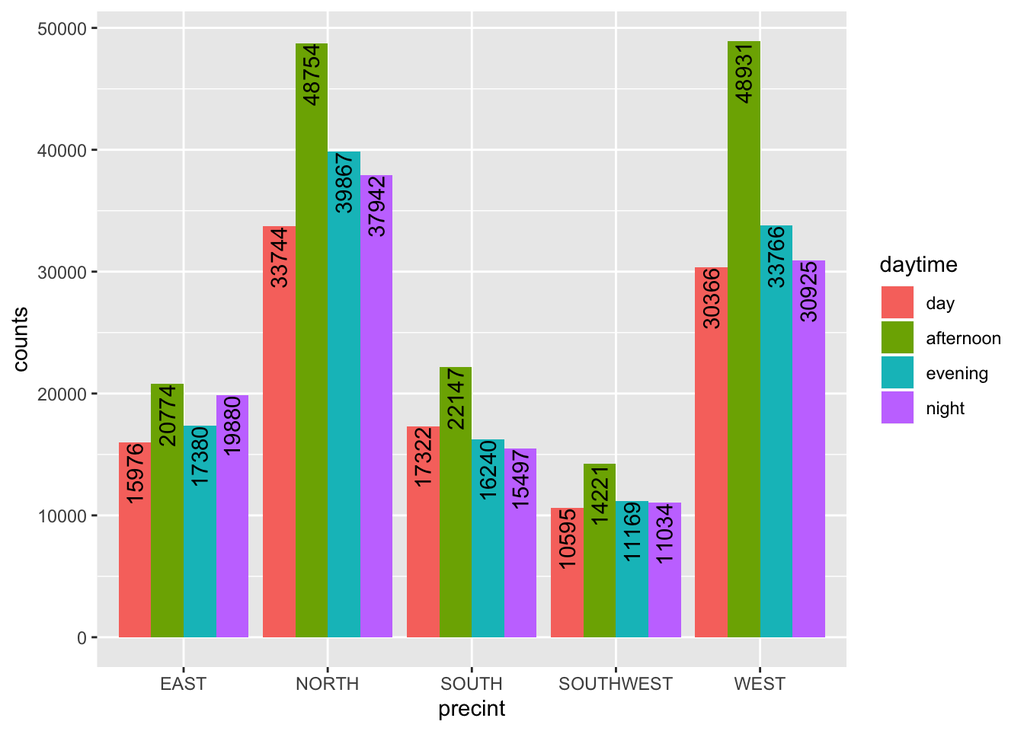

```r
# ggplot using data frame
# basic bar plot DODGED

library(ggplot2)
base1=ggplot(data=PrecDaytiDF,
             aes(x=precint,y=counts,fill=daytime)) # VARS NEEDED

barDodge= base1 +  geom_bar(stat="identity",
                            position="dodge") # NOT a default

barDodge= barDodge + geom_text(position = position_dodge(width = 0.9),
                               angle=90,
                               hjust=1,
                               aes(label=counts)) # its own AES!
barDodge
```

Or alternatively:

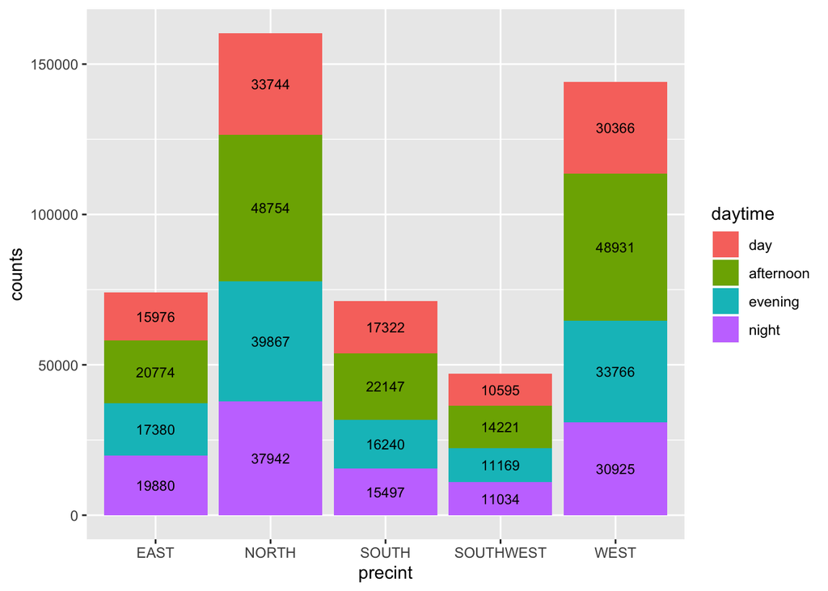

```r
# Stacked bar plot

barStacked = base1 + geom_bar(stat = "identity")  # stack is default
barStacked = barStacked + geom_text(size = 3,
                                    position = position_stack(vjust = 0.5),
                                    aes(label=counts))# its own AES!
barStacked
```

If you need percents, you can use this stacked version:

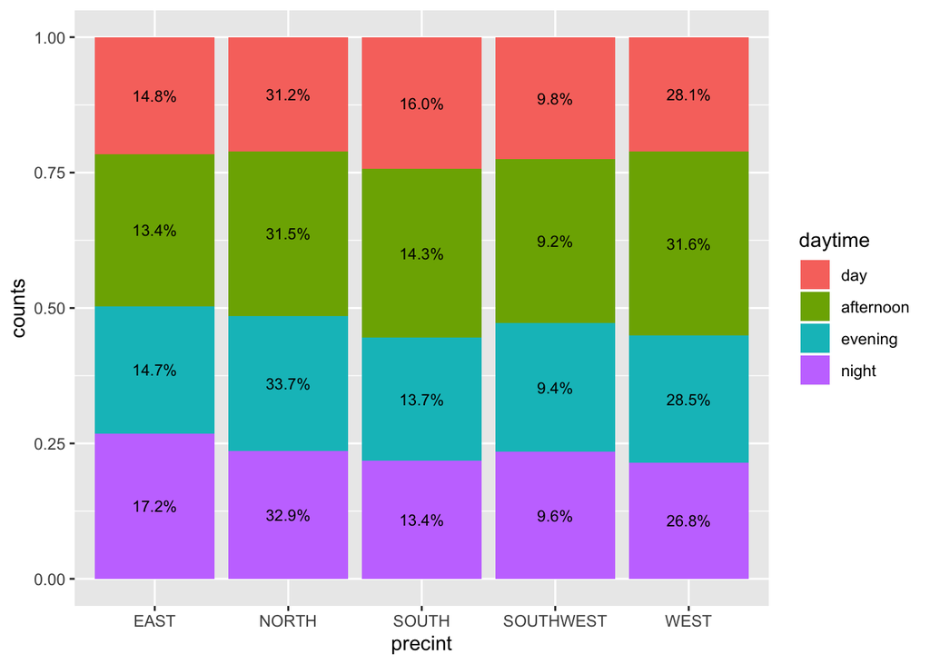

```r
#stacked percent
# they show the marginal table above: "PrecDayti_mgCol"
library(scales) # notice in 'percent()" below"

base2=ggplot(data=PrecDaytiDF,
             aes(fill=precint,y=counts,x=daytime)) # changes

barStackPct= base1 +  geom_bar(stat = "identity",
                       position="fill") # you need this

barStackPct= barStackPct + geom_text(size = 3,# check below:
                             position = position_fill(vjust = 0.5),
                             aes(label=percent(pctCol)))

barStackPct
```

Let me show you a more complex situation:

```r
# contingency table with many levels:

(CrimeDay=table(crime$crimecat,crime$Occurred.DayTime))
```

```
##
##                               day afternoon evening night
##   AGGRAVATED ASSAULT         3564      5366    4884  7501
##   ARSON                       196       167     191   486
##   BURGLARY                  24139     22288   14121 16082
##   CAR PROWL                 26740     38273   42595 34839
##   DISORDERLY CONDUCT           41        81      67    79
##   DUI                         706       939    2038  8522
##   FAMILY OFFENSE-NONVIOLENT  1748      2516    1217  1120
##   GAMBLE                        4         4       7     2
##   HOMICIDE                     41        46      49   131
##   LIQUOR LAW VIOLATION        112       491     410   606
##   LOITERING                    20        31      25     9
##   NARCOTIC                   2415      6416    3924  4109
##   PORNOGRAPHY                  65        53      17    31
##   PROSTITUTION                115       675    1425  1340
##   RAPE                        332       318     354   854
##   ROBBERY                    2584      4737    4139  5372
##   SEX OFFENSE-OTHER          1501      1759    1014  1776
##   THEFT                     38687     64868   38980 28410
##   TRESPASS                   4848      5184    2598  3289
##   WEAPON                      735      1445     947  1624
```

The previous contingency table has a categorical data with many levels, let’s prepare the data set:

```r
#making a data frame from contingency table

CrimeDayDF=as.data.frame(CrimeDay)
#renaming:
names(CrimeDayDF)=c("crime","daytime","counts")
#marginal
CrimeDay_mgCol=prop.table(CrimeDay,margin = 2)
#adding marginal
CrimeDayDF$pctCol=as.data.frame(CrimeDay_mgCol)[,3]

# result for ggplot:
head(CrimeDayDF)
```

```
##                crime daytime counts       pctCol
## 1 AGGRAVATED ASSAULT     day   3564 0.0328197950
## 2              ARSON     day    196 0.0018049046
## 3           BURGLARY     day  24139 0.2222887295
## 4          CAR PROWL     day  26740 0.2462405496
## 5 DISORDERLY CONDUCT     day     41 0.0003775566
## 6                DUI     day    706 0.0065013399
```

The complexity of two variables requires plots, as tables like these will not allow you to discover *association patterns* easily, even though they are already a summary of two columns. However, you must check the data format the plotting functions require, as most plots will use the contingency table as input (not the raw data).

As before, we can use the bar plot with the contingency table as input:

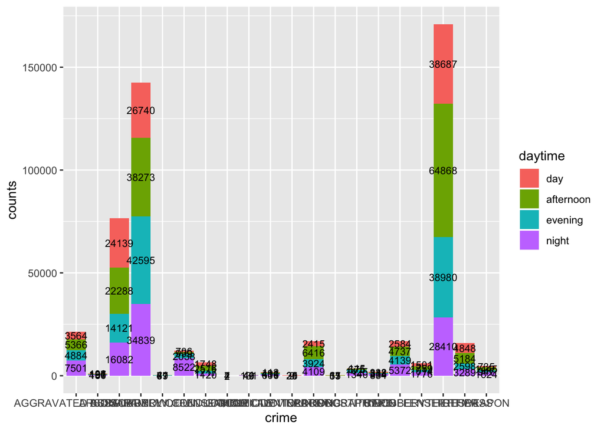

```r
# bad idea
base2=ggplot(data=CrimeDayDF,
             aes(x=crime,y=counts,fill=daytime))
base2 + geom_bar(stat = "identity") +
        geom_text(size = 3,
                  position = position_stack(vjust = 0.5),
                  aes(label=counts))
```

This plot will need a lot of work, so using the previous plots may not be a good strategy.

A first option you may have is to reproduce the table:

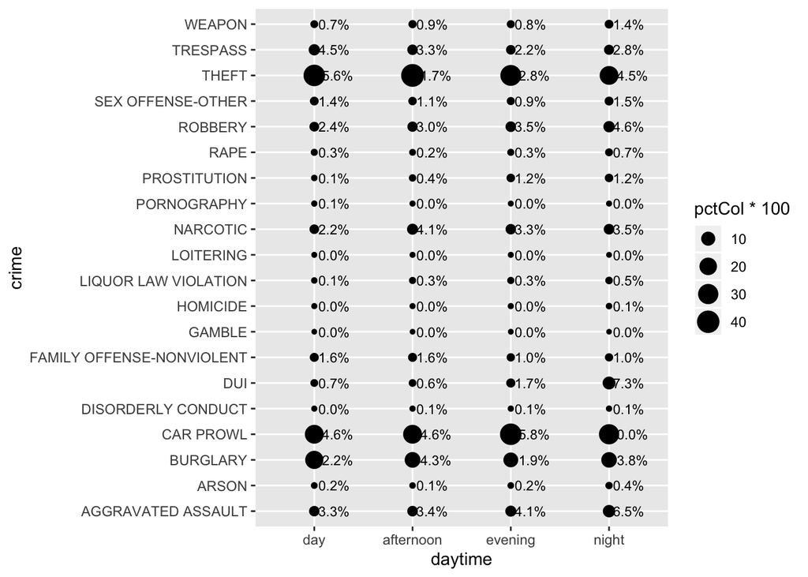

```r
# plotting a representation of contingency table:

library(ggplot2)
base3 = ggplot(CrimeDayDF, aes(x=daytime,y=crime))
# plot value as point, size by value of percent
tablePlot = base3 + geom_point(aes(size = pctCol*100))
# add value of Percent as label
tablePlot = tablePlot + geom_text(aes(label = percent(pctCol)),
                                    nudge_x = 0.2,
                                    size=3)
tablePlot
```

…some more work:

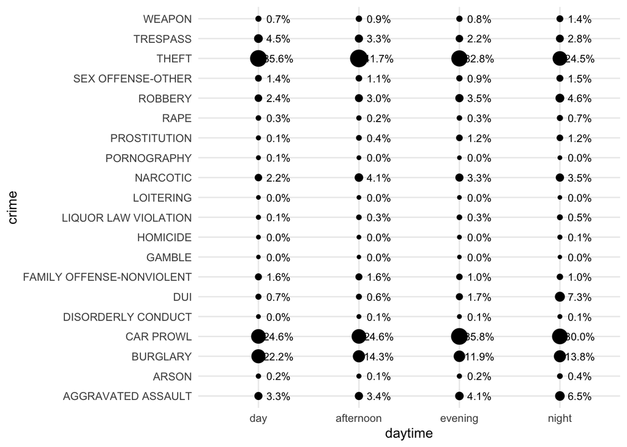

```r
# improving previous plot

tablePlot = tablePlot + theme_minimal() # less ink
tablePlot = tablePlot + theme(legend.position="none") # no legend
tablePlot
```

The plot looks nice, but unless the differences are clearly cut, you may see more noise than information, which distracts and delays decision making. Keep in mind that *length* of bars are easier to compare than circle *areas*. Do not discard the barplot, but with the help of **facets**:

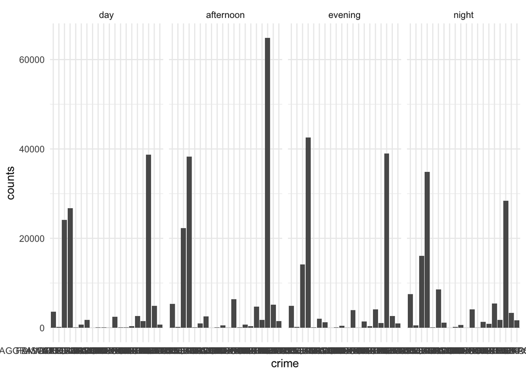

```r
# as usual for barplot (less info than base1)
base4 = ggplot(CrimeDayDF, aes(x = crime, y = counts ) )

#the bars
bars  = base4 + geom_bar( stat = "identity" ) + theme_minimal()

# bar per day time with 'facet'
barsFa = bars + facet_grid(~ daytime)

barsFa
```

…some more work:

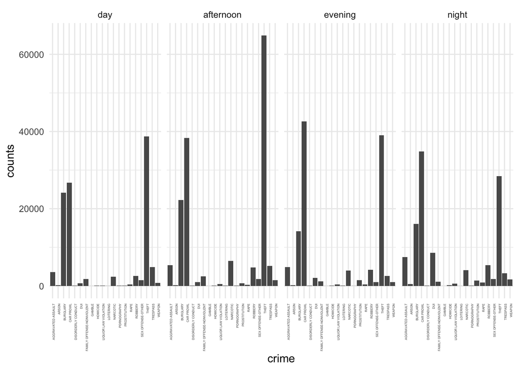

```r
# change the minimal theme

barsFa = barsFa + theme( axis.text.x = element_text(angle = 90,
                                                    hjust = 1,
                                                    size=3 ))
barsFa
```

And, the original relationship Input-Output table can be plotted like this:

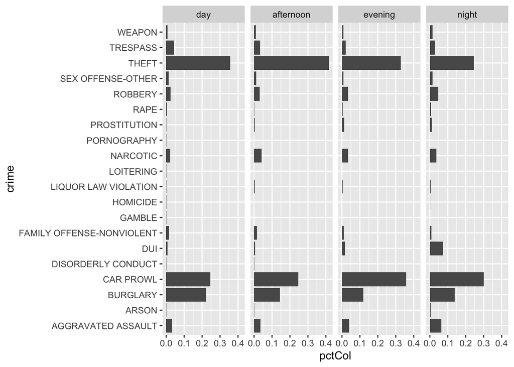

```r
# similar to base4
base5  = ggplot(CrimeDayDF, aes(x = crime,  y = pctCol ) )
barsIO = base5 + geom_bar( stat = "identity" )
barsIO = barsIO + facet_grid( ~ daytime)
barsIO = barsIO + coord_flip()

barsIO
```

The type of crime is not ordinal, then we could reorder the bars:

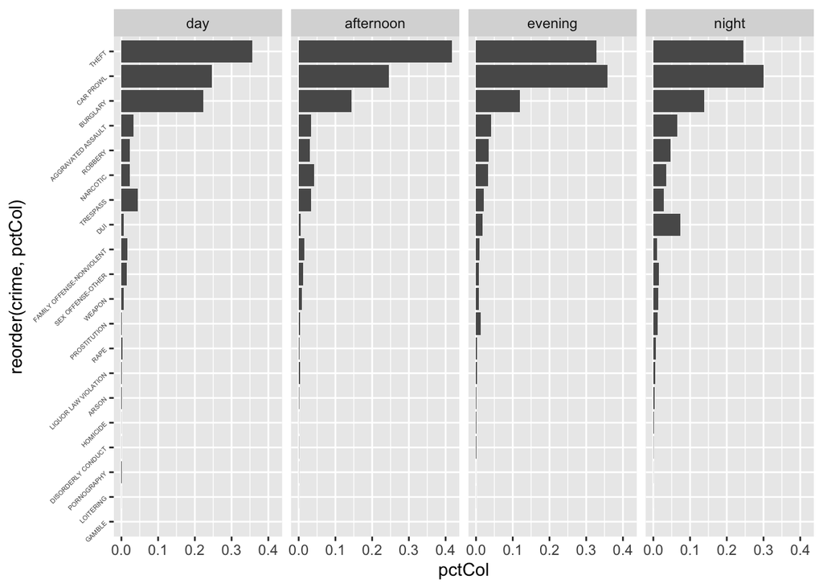

```r
# introducing "reorder""

#crime ordered by pctcl
base5b  = ggplot(CrimeDayDF,
                 aes(x = reorder(crime, pctCol), #here
                     y = pctCol ) )

barsIOb = base5b + geom_bar( stat = "identity" )
barsIOb = barsIOb + facet_grid( ~ daytime)
barsIOb= barsIOb + coord_flip()

# something extra:
barsIOb= barsIOb + theme(axis.text.y = element_text(size=4,angle = 45))
barsIOb
```

### Exercise 8: Turn the previous bar plot into a lollipop, add and remove elements as needed.

Once you see a complex plot of two bivariate categorical data, you may consider other plots.

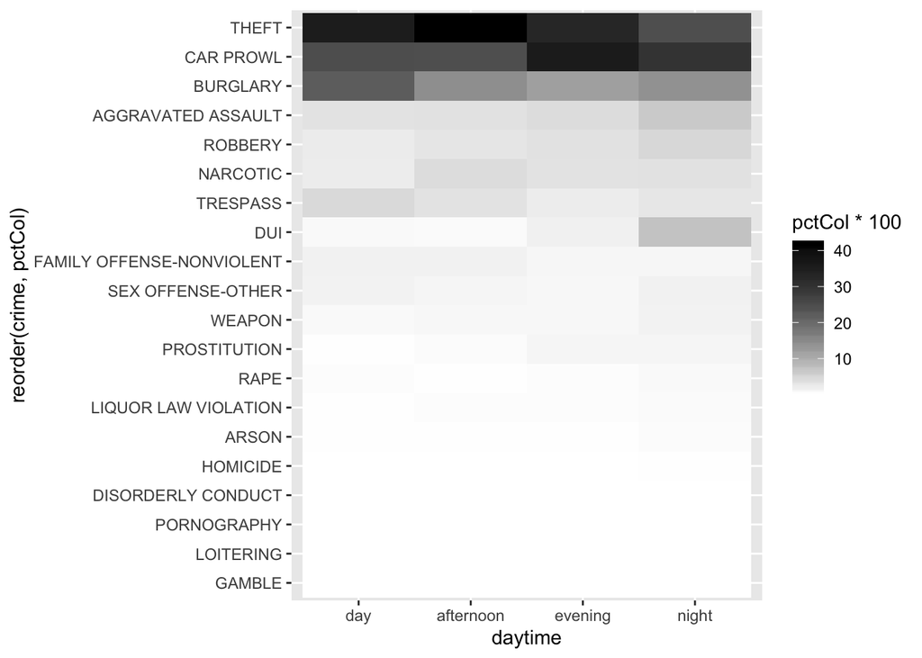

```r
# heatplot
base  = ggplot(CrimeDayDF, aes(x = daytime,
                               y = reorder(crime, pctCol),
                               fill = pctCol*100))
heat = base +  geom_tile()

# coloring intensity
heat = heat +scale_fill_gradient(low = "white",
                                   high = "black")
heat
```

Some improvement:

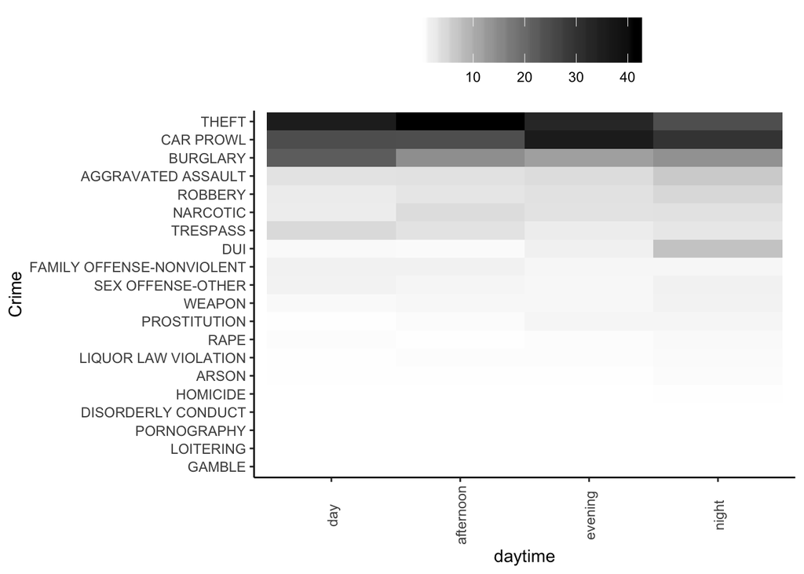

```r
# improving heat plot

heat = heat + theme_classic()
heat = heat + labs(y="Crime")
heat = heat + theme(axis.text.x = element_text(angle = 90,
                                               vjust = 0.6),
                      legend.title = element_blank(), #no leg. title
                      legend.position="top",
                      legend.direction="horizontal",
                      legend.key.width=unit(1, "cm"),
                      legend.key.height=unit(1, "cm"))

heat
```

### Group homework 1: Merge your data in one data frame. If you have two categorical variables, make a **contingency table**. If you do not have enough categorical variables, transform one or two using the **cut()** command and make a contingency table. Choose any of the plots in this lesson to plot that contingency table.